# CITES Wildlife Trade Database

The Convention on International Trade in Endangered Species of Wild Fauna and Flora CITES is an international treaty organisation tasked with monitoring, reporting and providing recommendations on the international species trade. It is one of the oldest conservation organisations in existence.

Participation is voluntary, but almost every member nation in the UN (and therefore almost every country worldwide) participates. Countries participating in CITES are obligated to report on roughly 5000 animal species and 29000 plant species brought into or exported out of their countries, and to honor limitations placed on the international trade of these species.

Protected species are organised into three appendixes:

- Appendix I species are those whose trade threatens them with extinction. Two particularly famous examples of Class I species are the black rhinoceros and the African elephant, whose extremely valuable tusks are an alluring target for poachers exporting ivory abroad.
- Appendix II species are those not threatened with extinction, but whose trade is nevertheless detrimental. Most species in CITES are in Appendix II.
- Appendix III animals are those submitted to CITES by member states as a control mechanism. Their export or import requires permits from the submitting member state(s).

The CITES records are publicly available via the [CITES Trade Database website](https://trade.cites.org/). The dataset we will be using for our analysis record all legal species imports and exports carried out in 2019 (`wildlife_trade_2019`) that were reported to CITES. Species not on the CITES lists and illegal black market trades are not included.

The dataset contains columns identifying the species, the import and export countries, and the amount and characteristics of the goods being traded (which range from live animals to skins and cadavers). A detailed description of each of the fields can be found in the [original CITES documentation](https://trade.cites.org/cites_trade_guidelines/en-CITES_Trade_Database_Guide.pdf).

```python
import pandas as pd
import numpy as np
import matplotlib.pyplot as plt
```

## 2019

```python
trade_2019 = pd.read_csv("datasets/CITES/wildlife_trade_2019.csv")
trade_2019.head()
```

|  | Year | App. | Taxon | Class | Order | Family | Genus | Importer | Exporter | Origin | Importer reported quantity | Exporter reported quantity | Term | Unit | Purpose | Source |
| --- | --- | --- | --- | --- | --- | --- | --- | --- | --- | --- | --- | --- | --- | --- | --- | --- |
| 0 | 2019 | I | Aquila adalberti | Aves | Falconiformes | Accipitridae | Aquila | CH | FR | MO | NaN | 1.0 | bodies | NaN | P | O |
| 1 | 2019 | I | Aquila heliaca | Aves | Falconiformes | Accipitridae | Aquila | CH | AT | UA | NaN | 1.0 | bodies | NaN | P | O |
| 2 | 2019 | I | Haliaeetus albicilla | Aves | Falconiformes | Accipitridae | Haliaeetus | IS | DK | XX | NaN | 252.0 | specimens | NaN | S | O |
| 3 | 2019 | I | Haliaeetus albicilla | Aves | Falconiformes | Accipitridae | Haliaeetus | IS | DK | XX | NaN | 30.0 | specimens | NaN | S | W |
| 4 | 2019 | I | Haliaeetus albicilla | Aves | Falconiformes | Accipitridae | Haliaeetus | XV | FR | DE | NaN | 1.0 | live | NaN | Q | C |

```python
# number of rows and columns
trade_2019.shape
```

```
(69475, 16)
```

```python
# columns in the dataframe
trade_2019.columns
```

```
Index(['Year', 'App.', 'Taxon', 'Class', 'Order', 'Family', 'Genus',
       'Importer', 'Exporter', 'Origin', 'Importer reported quantity',
       'Exporter reported quantity', 'Term', 'Unit', 'Purpose', 'Source'],
      dtype='object')
```

```python
# null values in the dataframe
trade_2019.isnull().sum()
```

```
Year                              0
App.                              0
Taxon                             0
Class                         31145
Order                            20
Family                          410
Genus                          1274
Importer                         75
Exporter                        483
Origin                        45122
Importer reported quantity    42704
Exporter reported quantity    18331
Term                              0
Unit                          61657
Purpose                        6753
Source                          539
dtype: int64
```

```python
# unique values in App. column
trade_2019["App."].unique()
```

```
array(['I', 'II', 'III', 'N'], dtype=object)
```

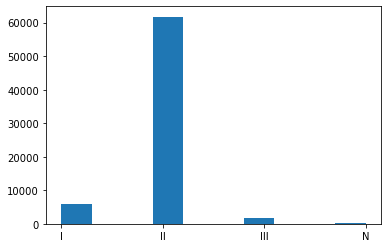

```python
# histogram to display frequency distribution for App. column
plt.hist(trade_2019["App."])
plt.show()
```

```python
# number of unique values in Taxon column
trade_2019["Taxon"].nunique()
```

```
7772
```

```python
# most commonly traded species
trade_2019["Taxon"].value_counts().head(25)
```

```
Crocodylus niloticus          2125
Alligator mississippiensis    1674
Dalbergia latifolia           1593
Python reticulatus            1582
Crocodylus porosus            1341
Acipenser baerii               941
Varanus salvator               849
Python bivittatus              813
Loxodonta africana             555
Acipenser gueldenstaedtii      553
Dalbergia spp.                 526
Varanus niloticus              522
Dalbergia melanoxylon          479
Caiman crocodilus yacare       445
Macaca fascicularis            439
Caiman crocodilus fuscus       424
Falco rusticolus               377
Aquilaria crassna              356
Vicugna vicugna                356
Phalaenopsis hybrid            350
Panthera leo                   343
Guibourtia demeusei            321
Scleractinia spp.              308
Aloe ferox                     288
Hippopotamus amphibius         263
Name: Taxon, dtype: int64
```

```python
trade_2019["Taxon"] = trade_2019["Taxon"].str.lower()
```

```python
# frequency table for values in Class column - 31145 null values are not displayed (default: dropna=True)
trade_2019["Class"].value_counts()
```

```
Reptilia          15036
Mammalia           7396
Aves               6974
Anthozoa           4433
Actinopteri        2815
Elasmobranchii      400
Amphibia            366
Bivalvia            293
Insecta             201
Gastropoda          198
Arachnida            93
Hydrozoa             48
Hirudinoidea         43
Cephalopoda          26
Holothuroidea         4
Dipneusti             4
Name: Class, dtype: int64
```

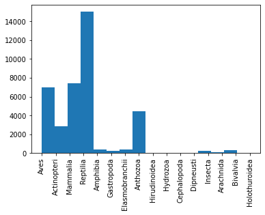

```python
plt.hist(trade_2019["Class"].dropna(), bins=trade_2019["Class"].nunique())
plt.xticks(rotation = 90)
plt.show()
```

```python
# number of unqiue values in Order column
trade_2019["Order"].nunique()
```

```
104
```

```python
# number of unqiue values in Family column
trade_2019["Family"].nunique()
```

```
263
```

```python
# number of unqiue values in Genus column
trade_2019["Genus"].nunique()
```

```
1313
```

```python
# top 10 importers
trade_2019["Importer"].value_counts().head(10)
```

```
DE    6083
US    5850
JP    5514
CH    2725
CN    2504
HK    2472
AE    2125
SG    1811
FR    1785
CA    1586
Name: Importer, dtype: int64
```

```python
top_10_importers = trade_2019["Importer"].value_counts().head(10).index.tolist()
top_10_importers
```

```
['DE', 'US', 'JP', 'CH', 'CN', 'HK', 'AE', 'SG', 'FR', 'CA']
```

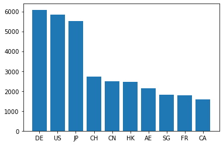

```python
plt.bar(top_10_importers, trade_2019["Importer"].value_counts().head(10))
plt.show()
```

```python
# top 10 exporters
trade_2019["Exporter"].value_counts().head(10)
```

```
NL    8015
TH    6535
IT    4052
FR    3737
ZA    3362
DE    2954
CO    2450
EC    2325
ID    2294
US    1613
Name: Exporter, dtype: int64
```

```python
top_10_exporters = trade_2019["Exporter"].value_counts().head(10).index.tolist()
top_10_exporters
```

```
['NL', 'TH', 'IT', 'FR', 'ZA', 'DE', 'CO', 'EC', 'ID', 'US']
```

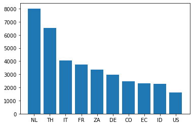

```python
plt.bar(top_10_exporters, trade_2019["Exporter"].value_counts().head(10))
plt.show()
```

```python
# top 10 origins
trade_2019["Origin"].value_counts().head(10)
```

```
XX    2136
US    2056
ID    1956
VN    1300
IN     982
ZW     930
AU     868
ZA     788
MY     719
CN     610
Name: Origin, dtype: int64
```

The `Origin` column has a large amount of null values:

```python
trade_2019["Origin"].isnull().sum()
```

```
45122
```

The code `XX` - which is the most frequently used code in the column as per our frequency table above - is used for entries with unknown origin. Let's replace the missing values in the column with this code instead.

```python
# replacing missing values with XX
trade_2019["Origin"] = trade_2019["Origin"].fillna("XX")
```

```python
# no remaining missing values
trade_2019["Origin"].isnull().sum()
```

```
0
```

```python
# revised frequency count for the XX code
trade_2019[trade_2019["Origin"] == "XX"].shape[0]
```

```
47258
```

```python
top_10_origins = trade_2019["Origin"][trade_2019["Origin"] != "XX"].value_counts().head(10).index.tolist()
top_10_origins
```

```
['US', 'ID', 'VN', 'IN', 'ZW', 'AU', 'ZA', 'MY', 'CN', 'FR']
```

```python
# importer reported quantity
```

```python
trade_2019[trade_2019["Importer reported quantity"] == trade_2019["Importer reported quantity"].min()]
```

|  | Year | App. | Taxon | Class | Order | Family | Genus | Importer | Exporter | Origin | Importer reported quantity | Exporter reported quantity | Term | Unit | Purpose | Source |
| --- | --- | --- | --- | --- | --- | --- | --- | --- | --- | --- | --- | --- | --- | --- | --- | --- |
| 26843 | 2019 | II | phyllobates terribilis | Amphibia | Anura | Dendrobatidae | Phyllobates | JP | FR | CO | 0.00004 | NaN | specimens | g | T | O |

```python
trade_2019[trade_2019["Importer reported quantity"] == trade_2019["Importer reported quantity"].max()]
```

|  | Year | App. | Taxon | Class | Order | Family | Genus | Importer | Exporter | Origin | Importer reported quantity | Exporter reported quantity | Term | Unit | Purpose | Source |
| --- | --- | --- | --- | --- | --- | --- | --- | --- | --- | --- | --- | --- | --- | --- | --- | --- |
| 64204 | 2019 | II | aquilaria filaria | NaN | Myrtales | Thymelaeaceae | Aquilaria | AE | SG | ID | 37875995.0 | NaN | chips | g | T | W |

```python
# exporter reported quantity
```

```python
trade_2019[trade_2019["Exporter reported quantity"] == trade_2019["Exporter reported quantity"].min()]
```

|  | Year | App. | Taxon | Class | Order | Family | Genus | Importer | Exporter | Origin | Importer reported quantity | Exporter reported quantity | Term | Unit | Purpose | Source |
| --- | --- | --- | --- | --- | --- | --- | --- | --- | --- | --- | --- | --- | --- | --- | --- | --- |
| 26835 | 2019 | II | phyllobates terribilis | Amphibia | Anura | Dendrobatidae | Phyllobates | AU | FR | CO | NaN | 1.000000e-08 | specimens | kg | T | O |

```python
trade_2019[trade_2019["Exporter reported quantity"] == trade_2019["Exporter reported quantity"].max()]
```

|  | Year | App. | Taxon | Class | Order | Family | Genus | Importer | Exporter | Origin | Importer reported quantity | Exporter reported quantity | Term | Unit | Purpose | Source |
| --- | --- | --- | --- | --- | --- | --- | --- | --- | --- | --- | --- | --- | --- | --- | --- | --- |
| 21395 | 2019 | II | chlorocebus aethiops | Mammalia | Primates | Cercopithecidae | Chlorocebus | EG | IN | XX | NaN | 240000000.0 | specimens | NaN | M | U |

```python
# unique values in unit column
trade_2019["Unit"].unique()
```

```
array([nan, 'kg', 'g', 'ml', 'mg', 'l', 'm3', 'cm3', 'microgrammes', 'm',
       'm2', 'metric tonnes'], dtype=object)
```

```python
# top 10 trade terms
trade_2019["Term"].value_counts().head(10)
```

```
live                        37705
leather products (small)     7642
wood product                 3508
specimens                    2362
trophies                     2218
skins                        2086
caviar                       1462
cosmetics                    1274
garments                     1102
raw corals                    809
Name: Term, dtype: int64
```

```python
# frequency table for values in purpose column
trade_2019["Purpose"].value_counts()
```

```
T    51278
P     3828
H     2421
S     1850
Z      965
Q      713
B      609
M      506
E      302
G      129
N       99
L       22
Name: Purpose, dtype: int64
```

```python
%%html
<style>
table {float:left}
</style>
```

**Purpose Codes**

| Code | Description |
| --- | --- |
| B | Breeding in captivity or artificial propagation |
| E | Educational |
| G | Botanical garden |
| H | Hunting trophy |
| L | Law enforcement / judicial / forensic |
| M | Medical (including biomedical research) |
| N | Reintroduction or introduction into the wild |
| P | Personal |
| Q | Circus or travelling exhibition |
| S | Scientific |
| T | Commercial |
| Z | Zoo |

```python
# frequency table for values in source column
trade_2019["Source"].value_counts()
```

```
A    24953
W    18068
C    15597
O     4093
F     1993
D     1951
R     1857
U      245
I      135
X       44
Name: Source, dtype: int64
```

**Source Codes (Simplified)**

| Code | Description |
| --- | --- |
| A | Plants as well as parts and derivatives thereof that are specimens of species included in Appendix I that have been propagated artificially for non-commercial purposes or specimens of species included… |
| C | Animals bred in captivity as well as parts and derivatives thereof. |
| D | Appendix-I animals bred in captivity for commercial purposes and Appendix-I plants artificially propagated for commercial purposes, as well as parts and derivatives thereof. |
| F | Animals born in captivity (F1 or subsequent generations) that do not fulfil the definition of 'bred in captivity' as well as parts and derivatives thereof. |
| I | Confiscated or seized specimens. |
| O | Pre-Convention specimens. |
| R | Ranched specimens: specimens of animals reared in a controlled environment, taken as eggs or juveniles from the wild, where they would otherwise have had a very low probability of surviving to adultho… |
| U | Source unknown. |
| W | Specimens taken from the wild. |
| X | Specimens taken in "the marine environment not under the jurisdiction of any State". |

The `Source` column has a code for unknown sources (`U`) but contains 539 null values:

```python
trade_2019["Source"].isnull().sum()
```

```
539
```

Let's replace these null values with the code `U`.

```python
trade_2019["Source"] = trade_2019["Source"].fillna("U")
```

```python
# confirming our cleaning worked - no remaining null values
trade_2019["Source"].isnull().sum()
```

```
0
```

```python
# confirming our cleaning worked - number of source code U is now 784 - 245 (original) + 539 (previous null values)
trade_2019[trade_2019["Source"] == "U"].shape[0]
```

```
784
```

```python
# crocodile / caiman / alligator type species traded
key_words = ["crocodylus", "alligator", "caiman"]
counter = 0
species_list = []

for _, row in trade_2019.iterrows():
    for word in key_words:
        if word in row["Taxon"]:
            counter += 1

            species_name = row["Taxon"]

            if species_name not in species_list:
                species_list.append(species_name)

print("Number of crocodile / alligator / caiman type species traded: ", counter)
print(species_list)
```

```
Number of crocodile / alligator / caiman type species traded:  6874
['alligator sinensis', 'crocodylus acutus', 'crocodylus intermedius', 'crocodylus mindorensis', 'crocodylus niloticus', 'crocodylus palustris', 'crocodylus porosus', 'crocodylus rhombifer', 'crocodylus siamensis', 'alligatoridae spp.', 'alligator mississippiensis', 'caiman crocodilus', 'caiman croco…
```

```python
crocs = []

for _, row in trade_2019.iterrows():
    if row["Taxon"] in species_list:
        crocs.append(row)
```

```python
crocs_df = pd.DataFrame(crocs, columns = trade_2019.columns)
crocs_df.reset_index(drop=True, inplace=True)
```

```python
crocs_df.head()
```

|  | Year | App. | Taxon | Class | Order | Family | Genus | Importer | Exporter | Origin | Importer reported quantity | Exporter reported quantity | Term | Unit | Purpose | Source |
| --- | --- | --- | --- | --- | --- | --- | --- | --- | --- | --- | --- | --- | --- | --- | --- | --- |
| 0 | 2019 | I | alligator sinensis | Reptilia | Crocodylia | Alligatoridae | Alligator | CH | SI | US | NaN | 11.0 | leather products (small) | NaN | T | W |
| 1 | 2019 | I | alligator sinensis | Reptilia | Crocodylia | Alligatoridae | Alligator | CZ | CN | XX | 5.0 | NaN | live | NaN | T | D |
| 2 | 2019 | I | alligator sinensis | Reptilia | Crocodylia | Alligatoridae | Alligator | JP | CN | XX | 5.0 | NaN | live | NaN | T | D |
| 3 | 2019 | I | alligator sinensis | Reptilia | Crocodylia | Alligatoridae | Alligator | MX | JP | CN | 1.0 | NaN | live | NaN | T | D |
| 4 | 2019 | I | crocodylus acutus | Reptilia | Crocodylia | Crocodylidae | Crocodylus | AE | IT | CO | 2.0 | 18.0 | leather products (small) | NaN | T | D |

```python
crocs_df["Term"].value_counts()
```

```
leather products (small)    4228
skins                        990
garments                     458
skin pieces                  346
leather products (large)     249
trophies                     136
jewellery                    125
live                          56
specimens                     48
bodies                        45
meat                          36
skulls                        34
sides                         33
tails                         25
carvings                      25
oil                           12
teeth                          6
bones                          6
eggs                           3
feet                           3
cosmetics                      3
derivatives                    2
medicine                       2
skeletons                      2
rug                            1
Name: Term, dtype: int64
```

```python
crocs_df[crocs_df["Term"] == "live"]["Purpose"].value_counts()
```

```
T    32
Z    12
Q     5
B     2
N     1
M     1
Name: Purpose, dtype: int64
```

```python
# top 10 exporters of non-live crocodiles
crocs_df[crocs_df["Term"] != "live"]["Exporter"].value_counts().head(10)
```

```
IT    1706
FR     978
SG     500
TH     422
CH     366
DE     243
JP     234
ZA     228
HK     215
ES     195
Name: Exporter, dtype: int64
```

```python
# top 10 importers of non-live crocodiles
crocs_df[crocs_df["Term"] != "live"]["Importer"].value_counts().head(10)
```

```
HK    465
JP    439
US    393
CN    360
FR    327
SG    296
IT    283
CH    273
AE    225
KR    222
Name: Importer, dtype: int64
```

```python
# countries that are both in the top 10 importers and top 10 exporters
imp_and_exp = []

for country in top_10_importers:
    if country in top_10_exporters:
        imp_and_exp.append(country)

imp_and_exp
```

```
['DE', 'US', 'FR']
```

```python
# purpose for these countries to import
for country in imp_and_exp:
    print(country)
    print(trade_2019[trade_2019["Importer"] == country]["Purpose"].value_counts())
    print("------------")
```

```
DE
T    5293
S     275
P     248
H     154
M      37
Q      26
Z      19
B      12
E       8
L       4
G       1
N       1
Name: Purpose, dtype: int64
------------
US
T    4692
S     419
P     319
H     244
M      80
Z      15
B      10
G       5
E       5
Q       5
L       2
Name: Purpose, dtype: int64
------------
FR
T    1389
P      91
Q      67
H      63
S      39
M      32
Z      24
E      18
Name: Purpose, dtype: int64
------------
```

```python
zoo_df = trade_2019[trade_2019["Purpose"] == "Z"]
```

```python
zoo_df[zoo_df["Term"] != "live"].shape[0]
```

```
161
```

```python
zoo_live_df = zoo_df[zoo_df["Term"] == "live"]
```

```python
zoo_live_df.shape[0]
```

```
804
```

```python
zoo_live_df["Taxon"].value_counts().head(15)
```

```
panthera leo               40
panthera tigris            29
lemur catta                15
acinonyx jubatus           12
spheniscus humboldti       10
panthera onca              10
varecia variegata          10
pan troglodytes            10
leptailurus serval          9
colobus guereza             9
panthera pardus             8
elephas maximus             7
panthera uncia              7
cercopithecus neglectus     7
aonyx cinerea               7
Name: Taxon, dtype: int64
```

```python
zoo_live_df["Class"].value_counts()
```

```
Mammalia          466
Aves              230
Reptilia           70
Amphibia           17
Anthozoa           15
Cephalopoda         3
Actinopteri         2
Elasmobranchii      1
Name: Class, dtype: int64
```

```python
zoo_live_df["Order"].value_counts()
```

```
Carnivora           212
Primates            182
Psittaciformes       95
Perissodactyla       22
Artiodactyla         21
Falconiformes        20
Sauria               19
Serpentes            18
Crocodylia           18
Ciconiiformes        17
Anura                17
Strigiformes         16
Scleractinia         15
Gruiformes           15
Testudines           15
Sphenisciformes      12
Cetacea              12
Coraciiformes        11
Galliformes          11
Columbiformes        10
Passeriformes         9
Proboscidea           8
Piciformes            5
Anseriformes          4
Cuculiformes          3
Nautilida             3
Chiroptera            3
Rodentia              3
Rheiformes            2
Pilosa                2
Scandentia            1
Acipenseriformes      1
Pristiformes          1
Syngnathiformes       1
Name: Order, dtype: int64
```

```python
zoo_live_df["Family"].value_counts().head(10)
```

```
Felidae            152
Psittacidae         72
Cercopithecidae     61
Cebidae             44
Lemuridae           30
Hominidae           20
Mustelidae          19
Hylobatidae         17
Ursidae             16
Strigidae           15
Name: Family, dtype: int64
```

```python
zoo_live_df["Genus"].value_counts().head(10)
```

```
Panthera         94
Cercopithecus    22
Ara              21
Amazona          16
Lemur            15
Acinonyx         12
Spheniscus       12
Saguinus         11
Saimiri          11
Varecia          11
Name: Genus, dtype: int64
```

```python
zoo_live_df["Exporter"].value_counts().head(10)
```

```
ZA    73
SG    56
CH    55
CZ    49
RU    45
DE    41
NL    32
FR    31
TH    28
AU    23
Name: Exporter, dtype: int64
```

Top exporter of live animals for zoos is South Africa, followed by Singapore and Switzerland.

```python
zoo_live_df["Importer"].value_counts().head(10)
```

```
SG    69
CN    60
ID    37
RU    37
CH    37
LK    36
UA    26
TH    25
PH    24
FR    24
Name: Importer, dtype: int64
```

Top importer of live animals for zoos is Singapore, followed by China and Indonesia.

```python
zoo_live_df["Source"].value_counts()
```

```
C    599
W     89
F     76
U     29
I      9
D      1
O      1
Name: Source, dtype: int64
```

Most zoo animals traded were bred in captivity. There were also 89 instances of traded animals taken from the wild, and 76 instances of traded animals born in captivity that do not fulfil the definition of 'bred in captivity'.

```python
zoo_live_df[(zoo_live_df["Importer reported quantity"] == 1.0) | (zoo_live_df["Exporter reported quantity"] == 1.0)].shape[0]
```

```
253
```

```python
zoo_live_df[((zoo_live_df["Importer reported quantity"] == 1.0) &
            ((zoo_live_df["Exporter reported quantity"] < 1.0) | (zoo_live_df["Exporter reported quantity"] > 1.0))) |
            ((zoo_live_df["Exporter reported quantity"] == 1.0) &
            ((zoo_live_df["Importer reported quantity"] < 1.0) | (zoo_live_df["Importer reported quantity"] > 1.0)))]
```

|  | Year | App. | Taxon | Class | Order | Family | Genus | Importer | Exporter | Origin | Importer reported quantity | Exporter reported quantity | Term | Unit | Purpose | Source |
| --- | --- | --- | --- | --- | --- | --- | --- | --- | --- | --- | --- | --- | --- | --- | --- | --- |
| 3318 | 2019 | I | panthera tigris | Mammalia | Carnivora | Felidae | Panthera | VN | ZA | XX | 1.0 | 4.0 | live | NaN | Z | C |
| 3325 | 2019 | I | panthera tigris | Mammalia | Carnivora | Felidae | Panthera | ZA | AR | XX | 1.0 | 2.0 | live | NaN | Z | F |
| 3741 | 2019 | I | lemur catta | Mammalia | Primates | Lemuridae | Lemur | AE | CZ | SE | 1.0 | 10.0 | live | NaN | Z | C |
| 3798 | 2019 | I | varecia variegata | Mammalia | Primates | Lemuridae | Varecia | ID | CZ | XX | 2.0 | 1.0 | live | NaN | Z | C |
| 21274 | 2019 | II | cercocebus torquatus | Mammalia | Primates | Cercopithecidae | Cercocebus | SG | PL | XX | 1.0 | 3.0 | live | NaN | Z | C |
| 30896 | 2019 | II | panthera leo | Mammalia | Carnivora | Felidae | Panthera | MK | DE | XX | 2.0 | 1.0 | live | NaN | Z | C |
| 31028 | 2019 | II | panthera leo | Mammalia | Carnivora | Felidae | Panthera | VN | ZA | XX | 9.0 | 1.0 | live | NaN | Z | C |

Around 253 animals appear to have been traded on their own.

```python
zoo_live_df[(zoo_live_df["Importer reported quantity"] == 2.0) | (zoo_live_df["Exporter reported quantity"] == 2.0)].shape[0]
```

```
217
```

```python
zoo_live_df[((zoo_live_df["Importer reported quantity"] == 2.0) &
            ((zoo_live_df["Exporter reported quantity"] < 2.0) | (zoo_live_df["Exporter reported quantity"] > 2.0))) |
            ((zoo_live_df["Exporter reported quantity"] == 2.0) &
            ((zoo_live_df["Importer reported quantity"] < 2.0) | (zoo_live_df["Importer reported quantity"] > 2.0)))]
```

|  | Year | App. | Taxon | Class | Order | Family | Genus | Importer | Exporter | Origin | Importer reported quantity | Exporter reported quantity | Term | Unit | Purpose | Source |
| --- | --- | --- | --- | --- | --- | --- | --- | --- | --- | --- | --- | --- | --- | --- | --- | --- |
| 3077 | 2019 | I | panthera onca | Mammalia | Carnivora | Felidae | Panthera | VN | ZA | XX | 2.0 | 4.0 | live | NaN | Z | C |
| 3263 | 2019 | I | panthera tigris | Mammalia | Carnivora | Felidae | Panthera | BD | ZA | XX | 4.0 | 2.0 | live | NaN | Z | C |
| 3325 | 2019 | I | panthera tigris | Mammalia | Carnivora | Felidae | Panthera | ZA | AR | XX | 1.0 | 2.0 | live | NaN | Z | F |
| 3798 | 2019 | I | varecia variegata | Mammalia | Primates | Lemuridae | Varecia | ID | CZ | XX | 2.0 | 1.0 | live | NaN | Z | C |
| 5589 | 2019 | I | leucopsar rothschildi | Aves | Passeriformes | Sturnidae | Leucopsar | SG | DK | XX | 2.0 | 4.0 | live | NaN | Z | C |
| 30417 | 2019 | II | leptailurus serval | Mammalia | Carnivora | Felidae | Leptailurus | JP | ZA | XX | 4.0 | 2.0 | live | NaN | Z | C |
| 30896 | 2019 | II | panthera leo | Mammalia | Carnivora | Felidae | Panthera | MK | DE | XX | 2.0 | 1.0 | live | NaN | Z | C |
| 31040 | 2019 | II | panthera leo | Mammalia | Carnivora | Felidae | Panthera | ZA | AR | XX | 2.0 | 3.0 | live | NaN | Z | F |
| 58401 | 2019 | II | morelia spilota | Reptilia | Serpentes | Pythonidae | Morelia | LK | RU | XX | 3.0 | 2.0 | live | NaN | Z | C |

Roughly 217 animals appear to have been traded in pairs.

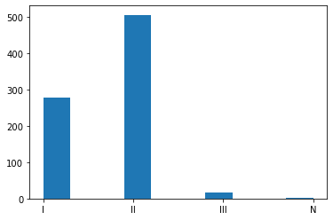

```python
plt.hist(zoo_live_df["App."])
plt.show()
```